# EnyeartKaggleRMD

Jack Enyeart

5/24/2017

# Read in the data

```r
sberCC = read.csv('trainCC.csv', stringsAsFactors = FALSE)
```

# Basic investigation of the data frame

```r
str(sberCC)
names(sberCC)
dim(sberCC)
```

Look at all columns to see what additional changes need to be made: All variables, with class type and index:

```r
for (i in c(1:length(names(sberCC)))){
  print(c(names(sberCC)[i],class(sberCC[,i]),i))
}
```

First step of lasso/ridge: x = model.matrix(price_doc ~ ., sberCC)[, -1] returns the error: contrasts can be applied only to factors with 2 or more levels

Which variable is of type “character” that has only one class?

```r
for (i in c(1:length(names(sberCC)))){
  if ((length(unique(sberCC[,i]))) == 1) {
  print(names(sberCC)[i])
  }
}
```

```
## [1] "incineration_raion"
```

“incineration_raion” is the bad column (~28500 ‘no’, ~2500 ‘yes’ in the original) in the complete cases: incineration_raion contains all ‘no’, so remove it. Also drop id, it’s meaningless:

```r
sberCC = select(sberCC, -incineration_raion)
sberCC = select(sberCC, -id)
```

# Fix the date column:

Convert timestamp colummn to the appropriate format:

```r
sberCC$timestamp = as.Date(sberCC$timestamp)

dateconversion <- function(x){
  return(as.numeric(julian(x,origin = sberCC$timestamp[1])))
}

#Apply to the timestamp column, and refine column
sberCC$timestamp = sapply(sberCC$timestamp,dateconversion)
```

# Creating the data matrices for the glmnet() function.

```r
x = model.matrix(price_doc ~ ., sberCC)[, -1]
y = sberCC$price_doc

#Creating training and test sets with an 80-20 split, respectively.
set.seed(0)
train = sample(1:nrow(x), 8*nrow(x)/10)
test = (-train)
y.test = y[test]
length(train)/nrow(x)
```

```
## [1] 0.7998636
```

```r
length(y.test)/nrow(x)
```

```
## [1] 0.2001364
```

```r
#Values of lambda over which to check.
grid = 10^seq(10, 2, length = 100)
```

# Lasso

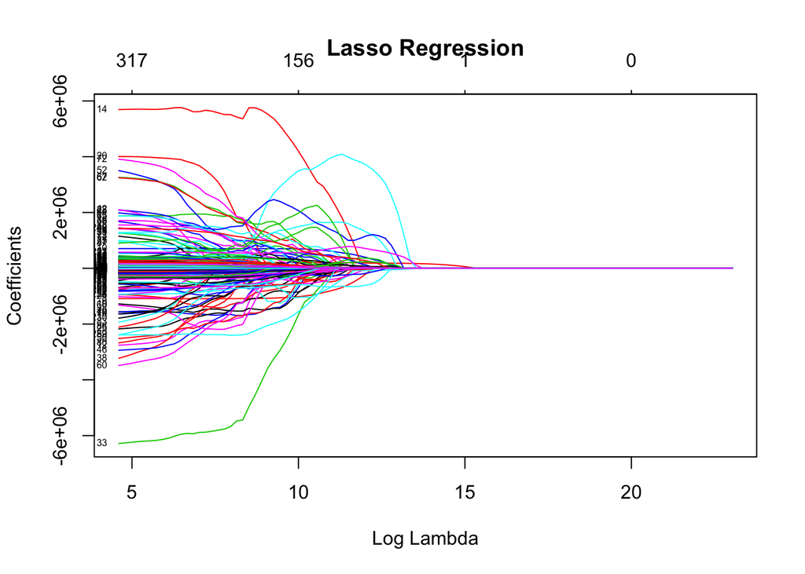

```r
lasso.models = glmnet(x[train, ], y[train], alpha = 1, lambda = grid)
plot(lasso.models, xvar = "lambda", label = TRUE, main = "Lasso Regression")
```

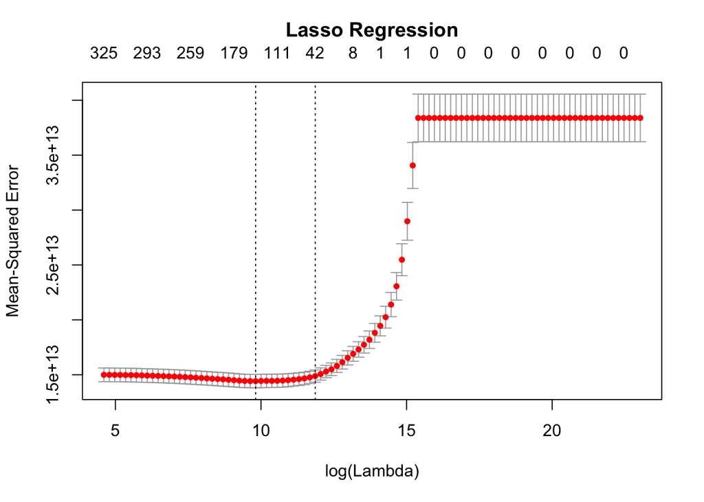

```r
set.seed(0)
cv.lasso.out = cv.glmnet(x[train, ], y[train], alpha = 1, nfolds = 10, lambda = grid)
plot(cv.lasso.out, main = "Lasso Regression\n")
```

```r
bestlambda.lasso = cv.lasso.out$lambda.min
bestlambda.lasso
```

```
## [1] 18307.38
```

```r
log(bestlambda.lasso)
```

```
## [1] 9.81506
```

```r
#MSE is locally minimized when log(lambda) ~= 9.81
```

```r
lasso.out = glmnet(x, y, alpha = 1)
lasso.coef = predict(lasso.out, type = "coefficients", s = bestlambda.lasso)[1:371,]

lasso.bestlambda = predict(lasso.out, s = bestlambda.lasso, newx = x)
mean((lasso.bestlambda - y)^2)
```

```
## [1] 1.311372e+13
```

Define a function that returns nonzero coeffcients of a lasso model for a given lambda (MSE not included):

```r
nonzeroCs <- function(lambda) {
  P = predict(lasso.out, type = "coefficients", s = lambda)
  P = as.matrix(P)
  P = as.data.frame(P)
  P$varname = rownames(P)
  rownames(P) <- 1:nrow(P)
  return(P[P[1] != 0,]$varname)
}
```

```r
for (ele in grid){
  if (length(nonzeroCs(ele)) < 25) {
    print(nonzeroCs(ele))
    print(ele)
    print('')
  }
}
```

# Selected Features from Lasso

```r
# LassoCoefs = nonzeroCs(298364.7)
# [1] "(Intercept)"                 "timestamp"                   "full_sq"
# [4] "kitch_sq"                    "state"                       "sub_areaHamovniki"
# [7] "sub_areaLomonosovskoe"       "sub_areaPresnenskoe"         "ID_metro"
# [10] "sadovoe_km"                  "office_km"                   "ecologysatisfactory"
# [13] "trc_sqm_500"                 "church_count_500"            "leisure_count_500"
# [16] "trc_sqm_1000"                "cafe_count_1000_price_high"  "prom_part_2000"
# [19] "office_sqm_5000"             "cafe_sum_5000_min_price_avg" "mosque_count_5000"
# [22] "sport_count_5000"

# Note that all variables with "sub_area<<INSERTNAME>>" are part of the same original
# feature (i.e. remove all of them and insert "sub_area")
```

# Reproducing Troy’s Tree

```r
#Get complete cases of dtrain
# Set training control so that we only 1 run forest on the entire set of complete cases
trControl <- trainControl(method='none')

# Run random forest on complete cases of sberCC. Exclude incineration_raion since it
# only has 1 factor level
rfmod <- train(price_doc ~ . - timestamp,
               method='rf',
               data=sberCC,
               trControl=trControl,
               tuneLength=1,
               importance=TRUE)

varImp(rfmod)
#Idea: Pick 20 top from RF, ~top 20 from lasso, take a union of that set:
```

```r
#PICK IMPORTANT COEFFICIENTS FROM EACH
OverallCoefs = union(RFCoefs,LassoCoefs)

#Forward Selection to further parse down

sberFeatSelected = sberCC[which(colnames(sberCC) %in% OverallCoefs)]

#Convert state to character
sberFeatSelected$state = as.character(sberFeatSelected$state)

#Best Feature Selection:

regfit.fwd = regsubsets(price_doc~., data = sberFeatSelected, nvmax = 20, method = "forward")
summary(regfit.fwd)
coef(regfit.fwd, 10)
coef(regfit.fwd, 20)
```

```r
#Settle on the following coefficients
FinalCoefs = c('timestamp',
               'full_sq',
               'state',
               'sub_area',
               'sadovoe_km',
               'oil_chemistry_km',
               'church_count_500',
               'leisure_count_500',
               'prom_part_3000',
               'office_sqm_5000',
               'mosque_count_5000',
               'price_doc')
```

# Moving on to multiple linear regression

```r
#Before running a multilinear regression, we should investigate missingness of these variables:
#Loading in data set
train_cleanedO = read.csv('train_cleaned.csv', stringsAsFactors = FALSE)
train_cleaned = read.csv('train_cleaned.csv', stringsAsFactors = FALSE)
train_cleaned = train_cleaned[which(colnames(train_cleaned) %in% FinalCoefs)]
```

```r
# Investigate missingness
colSums(is.na(train_cleaned))
```

Reformat the timestamp column to numeric

```r
train_cleaned$timestamp = as.Date(train_cleaned$timestamp)
#Define a function that we can sapply
dateconversion2 <- function(x){
  return(as.numeric(julian(x,origin = as.Date(train_cleanedO$timestamp[1]))))
}
#Apply to the timestamp column, and refine column
train_cleaned$timestamp = sapply(train_cleaned$timestamp,dateconversion2)
```

Take care of Missingness

```r
#Convert state to character (categorical variable):
train_cleaned$state[is.na(train_cleaned$state)] = 5
train_cleaned$state = as.character(train_cleaned$state)

## Take complete cases to eliminate the few (43 in total) rows that had NAs for full_sq
train_cleaned = train_cleaned[complete.cases(train_cleaned),]
```

Load in the test data, do similar cleaning:

```r
test_cleanedO = read.csv('test_cleaned.csv', stringsAsFactors = FALSE)
```

Cleaning:

```r
#Convert the state variable to character
test_cleanedO$state[is.na(test_cleanedO$state)] = 5
test_cleanedO$state = as.character(test_cleanedO$state)

##########Imputing the missing values for full_sq:  ####################

#Identify the missing valueS:
filter(test_cleanedO,is.na(test_cleanedO$full_sq))[,1:10]
```

```
##      id  timestamp full_sq life_sq floor max_floor material build_year
## 1 30938 2015-08-05      NA   37.80     7        19        1         NA
## 2 34670 2016-01-25      NA  122.60     3         3        2       2010
## 3 35108 2016-02-02      NA      NA     7        NA        1         NA
## 4 35857 2016-02-18      NA   42.07    18        18        1         NA
## 5 36824 2016-03-21      NA    2.00     5         5        1         NA
##   num_room kitch_sq
## 1        1      0.0
## 2        5     34.8
## 3        2      1.0
## 4        3      1.0
## 5        2      2.0
```

```r
#Imputing the first 3 by life_sq, the last 2 by median full_sq
test_cleanedO[test_cleanedO$id == 30938,]$full_sq = 37.80
test_cleanedO[test_cleanedO$id == 35857,]$full_sq = 42.07
test_cleanedO[test_cleanedO$id == 34670,]$full_sq = 122.60
test_cleanedO[test_cleanedO$id == 35108,]$full_sq = median(test_cleanedO$full_sq, na.rm = TRUE)
test_cleanedO[test_cleanedO$id == 36824,]$full_sq = median(test_cleanedO$full_sq, na.rm = TRUE)

test_cleaned = test_cleanedO[which(colnames(test_cleanedO) %in% FinalCoefs)]

# Reformat the timestamp column to numeric
test_cleaned$timestamp = as.Date(test_cleaned$timestamp)

#Apply to the timestamp column, and refine column
test_cleaned$timestamp = sapply(test_cleaned$timestamp,dateconversion2)
```

# Performing the multilinear regression

```r
n = names(train_cleaned[,c(c(1:4),c(6:12))])
f<-as.formula(paste("price_doc ~", paste(n[!n %in% "y"],collapse = "+")))
f
```

```
## price_doc ~ timestamp + full_sq + state + sub_area + church_count_500 +
##     leisure_count_500 + mosque_count_5000 + office_sqm_5000 +
##     oil_chemistry_km + prom_part_3000 + sadovoe_km
```

```r
model.saturated = lm(f, data = train_cleaned)
#summary(model.saturated)
#influencePlot(model.saturated)
```

# Predict on the test set

```r
LinModel1 = as.data.frame(predict(model.saturated, test_cleaned))
LinModel1$id = test_cleanedO$id
names(LinModel1) = c('price_doc','id')
LinModel1 = LinModel1[,c(2,1)]

# Reassigning the 'too-low' predictions
LinModel1[LinModel1$price_doc < 100000,]$price_doc = 100000

#write.csv(LinModel1,file = 'LinModel1.csv', row.names = FALSE)
```

We’ve previous predicted prices (i.e. picked coeffcients) minimizing RSS. Let’s predict log(price) in order to use the correct Kaggle metric.

# Multiple Linear Regression on Log(price)

```r
train2 = train_cleaned
train2$price_doc = log(train2$price_doc+1)

n = names(train_cleaned[,c(c(1:4),c(6:12))])
f3<-as.formula(paste("price_doc ~", paste(n[!n %in% "y"],collapse = "+")))
f3
```

```
## price_doc ~ timestamp + full_sq + state + sub_area + church_count_500 +
##     leisure_count_500 + mosque_count_5000 + office_sqm_5000 +
##     oil_chemistry_km + prom_part_3000 + sadovoe_km
```

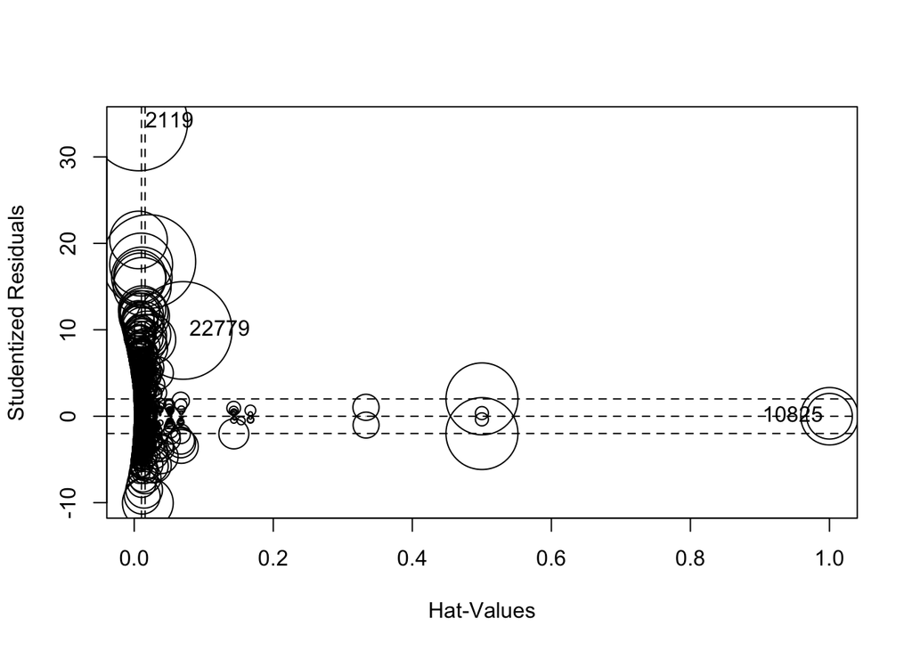

```
##         StudRes         Hat      CookD
## 2119  34.038798 0.006605654 0.04667084
## 10825  0.000000 1.000000000 0.01618425
## 22779  9.922731 0.070408586 0.04675227
```

```r
model.saturated3 = lm(f3, data = train2)
#summary(model.saturated3)
influencePlot(model.saturated)
```

```r
LogLinModel = as.data.frame(predict(model.saturated3, test_cleaned))
LogLinModel$id = test_cleanedO$id
names(LogLinModel) = c('price_doc','id')
LogLinModel = LogLinModel[,c(2,1)]
LogLinModel$price_doc = exp(LogLinModel$price_doc)-1

#write.csv(LogLinModel,file = 'LogLinModel.csv', row.names = FALSE)
```